# Spark_Lab_OpenAQ_S3(4)

## Spark Lab: Open Air Quality data set, reading data from S3

```python
import matplotlib.pyplot as plt
import pandas as pd
```

### Download and initialize Spark

```python
# Install OpenJDK 8 (Spark still works well with Java 8, though Java 11 is also supported)
!apt-get install openjdk-8-jdk-headless -qq > /dev/null

# Download Spark 3.5.1 with Hadoop 3.3
!wget -q https://archive.apache.org/dist/spark/spark-3.5.1/spark-3.5.1-bin-hadoop3.tgz
!tar -xvf spark-3.5.1-bin-hadoop3.tgz > /dev/null

# Install findspark and seaborn quietly
!pip install -q findspark > /dev/null
!pip install seaborn > /dev/null

!wget -q https://repo1.maven.org/maven2/org/apache/hadoop/hadoop-aws/3.3.4/hadoop-aws-3.3.4.jar -P /content/spark-3.5.1-bin-hadoop3/jars/
!wget -q https://repo1.maven.org/maven2/com/amazonaws/aws-java-sdk-bundle/1.12.262/aws-java-sdk-bundle-1.12.262.jar -P /content/spark-3.5.1-bin-hadoop3/jars/

# Install pyngrok (for exposing Spark UI)
!pip install pyngrok > /dev/null
```

```python
# Set up environment variables for Spark
import os
os.environ["JAVA_HOME"] = "/usr/lib/jvm/java-8-openjdk-amd64"
os.environ["SPARK_HOME"] = "/content/spark-3.5.1-bin-hadoop3"

# Initialize findspark and start a SparkSession
import findspark
findspark.init()
from pyspark.sql import SparkSession

# Create SparkSession
spark = SparkSession.builder \
    .appName("UpdatedSparkApp") \
    .getOrCreate()

# Verify the Spark version
print("Spark Version:", spark.version)
```

```
Spark Version: 3.5.1
```

### Configure AWS credentials

**Important**: you need to copy your AWS credentials to file named `aws_credentials`. Format:

```
aws_access_key_id=<access_key>
aws_secret_access_key=<secret_key>
aws_session_token=<session_token>
```

In AWS Academy you can find your credentials under AWS Details -> AWS CLI -> Show button

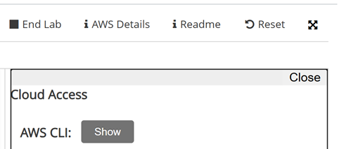

```python
# Read credentials from the file
credentials = {}
with open("/content/aws_credentials", "r") as f:
    for line in f:
        key, value = line.strip().split("=", 1)
        credentials[key] = value

# Extract credentials
AWS_ACCESS_KEY = credentials["aws_access_key_id"]
AWS_SECRET_KEY = credentials["aws_secret_access_key"]
AWS_SESSION_TOKEN = credentials["aws_session_token"]
```

```python
spark.sparkContext._jsc.hadoopConfiguration().set("fs.s3a.access.key", AWS_ACCESS_KEY)
spark.sparkContext._jsc.hadoopConfiguration().set("fs.s3a.secret.key", AWS_SECRET_KEY)
spark.sparkContext._jsc.hadoopConfiguration().set("fs.s3a.session.token", AWS_SESSION_TOKEN)
# Additional S3A configuration (optional but recommended)
# spark.sparkContext._jsc.hadoopConfiguration().set("fs.s3a.impl", "org.apache.hadoop.fs.s3a.S3AFileSystem")
```

### Reading OpenAQ data from AWS S3

OpenAQ project: https://openaq.org/

Registry of AWS Open Data: https://registry.opendata.aws/openaq/

S3 bucket structure: https://docs.openaq.org/aws/about

Now we can read a small sample of data:

```python
smog_df = spark \
    .read \
    .format("csv") \
    .option("compression", "gzip") \
    .option("header", True) \
    .load("s3a://openaq-data-archive/records/csv.gz/locationid=100*/year=2022/month=05/location-100*-2022050*.csv.gz")

    # Data from one day in one location:
    #.load("s3a://openaq-data-archive/records/csv.gz/locationid=2178/year=2022/month=05/location-2178-20220503.csv.gz")

    # Data from May 2022 from multiple locations:
    #.load("s3a://openaq-data-archive/records/csv.gz/locationid=10*/year=2022/month=05/*.csv.gz")
```

```python
smog_df.count()
```

```
1500
```

```python
smog_df.printSchema()
```

```
root
 |-- location_id: string (nullable = true)
 |-- sensors_id: string (nullable = true)
 |-- location: string (nullable = true)
 |-- datetime: string (nullable = true)
 |-- lat: string (nullable = true)
 |-- lon: string (nullable = true)
 |-- parameter: string (nullable = true)
 |-- units: string (nullable = true)
 |-- value: string (nullable = true)
```

```python
# Sample 1% of the data and show 10 records
smog_df.sample(fraction=0.01).limit(10).show(truncate=False)
```

```
+-----------+----------+--------------------------+-------------------------+----------------+----------------+---------+-----+------+
|location_id|sensors_id|location                  |datetime                 |lat             |lon             |parameter|units|value |
+-----------+----------+--------------------------+-------------------------+----------------+----------------+---------+-----+------+
|100        |4231      |Badhoevedorp-Sloterweg-100|2022-05-07T15:00:00+02:00|52.334          |4.77401         |pm10     |µg/m³|-999.0|
|100        |162       |Badhoevedorp-Sloterweg-100|2022-05-05T20:00:00+02:00|52.334          |4.77401         |co       |µg/m³|-999.0|
|1006       |1811      |Painesville-1006          |2022-05-07T10:00:00-04:00|41.726811       |-81.242156      |o3       |ppm  |0.041 |
|1006       |1812      |Painesville-1006          |2022-05-05T20:00:00-04:00|41.726811       |-81.242156      |so2      |ppm  |0.001 |
|1006       |1813      |Painesville-1006          |2022-05-09T18:00:00-04:00|41.726811       |-81.242156      |pm25     |µg/m³|6.7   |
|1000       |1803      |Presque Isle Riversi-1000 |2022-05-03T17:00:00-04:00|46.682299       |-68.016195      |pm10     |µg/m³|27.0  |
|1000       |1802      |Presque Isle Riversi-1000 |2022-05-03T11:00:00-04:00|46.682299       |-68.016195      |pm25     |µg/m³|1.0   |
|1004       |4662      |Padre Las Casas II-1004   |2022-05-05T11:00:00-01:00|-38.764767451719|-72.598795682209|pm10     |µg/m³|28.0  |
|1004       |1808      |Padre Las Casas II-1004   |2022-05-05T17:00:00-01:00|-38.764767451719|-72.598795682209|pm25     |µg/m³|30.0  |
|1003       |1807      |Padonia-1003              |2022-05-03T05:00:00-04:00|39.462002       |-76.631599      |pm25     |µg/m³|9.0   |
+-----------+----------+--------------------------+-------------------------+----------------+----------------+---------+-----+------+
```

### Using extended locations data

Data in the S3 bucket contains only a few necessary fields -- parameter readings and a limited information about sensor locations.

Additional information are available through OpenAQ API: https://api.openaq.org/

File `openaq_locations.json` contains extended information about locations which was downloaded using this REST API.

Data from this file joined with data in S3 can be used for more advanced queries.

For start let's locate all locations in Kraków.

```python
from pyspark.sql.functions import col, asc, desc, max
```

```python
# Download and upack OpenAQ locations data file
!wget https://github.com/dice-dydakt/datasets/raw/refs/heads/main/openaq_locations.json.gz && gunzip -f openaq_locations.json.gz
```

```
--2025-11-12 14:30:47--  https://github.com/dice-dydakt/datasets/raw/refs/heads/main/openaq_locations.json.gz
Resolving github.com (github.com)... 20.205.243.166
Connecting to github.com (github.com)|20.205.243.166|:443... connected.
HTTP request sent, awaiting response... 302 Found
Location: https://raw.githubusercontent.com/dice-dydakt/datasets/refs/heads/main/openaq_locations.json.gz [following]
--2025-11-12 14:30:48--  https://raw.githubusercontent.com/dice-dydakt/datasets/refs/heads/main/openaq_locations.json.gz
Resolving raw.githubusercontent.com (raw.githubusercontent.com)... 185.199.108.133, 185.199.109.133, 185.199.110.133, ...
Connecting to raw.githubusercontent.com (raw.githubusercontent.com)|185.199.108.133|:443... connected.
HTTP request sent, awaiting response... 200 OK
Length: 1834423 (1.7M) [application/octet-stream]
Saving to: ‘openaq_locations.json.gz’

openaq_locations.js 100%[===================>]   1.75M  --.-KB/s    in 0.009s

2025-11-12 14:30:48 (204 MB/s) - ‘openaq_locations.json.gz’ saved [1834423/1834423]
```

```python
# Let's load the file as Spark dataframe and print the schema
# Note: the file is small, so we could have used Pandas for this
# However, having a spark dataframe allows joining it with smog_df

df = spark.read.option("multiLine", True).json("openaq_locations.json")
display(df.select("id").distinct().count())
df.printSchema()
```

```
18798
```

```
root
 |-- bounds: array (nullable = true)
 |    |-- element: double (containsNull = true)
 |-- coordinates: struct (nullable = true)
 |    |-- latitude: double (nullable = true)
 |    |-- longitude: double (nullable = true)
 |-- country: struct (nullable = true)
 |    |-- code: string (nullable = true)
 |    |-- id: long (nullable = true)
 |    |-- name: string (nullable = true)
 |-- datetimeFirst: struct (nullable = true)
 |    |-- local: string (nullable = true)
 |    |-- utc: string (nullable = true)
 |-- datetimeLast: struct (nullable = true)
 |    |-- local: string (nullable = true)
 |    |-- utc: string (nullable = true)
 |-- distance: string (nullable = true)
 |-- id: long (nullable = true)
 |-- instruments: array (nullable = true)
 |    |-- element: struct (containsNull = true)
 |    |    |-- id: long (nullable = true)
 |    |    |-- name: string (nullable = true)
 |-- isMobile: boolean (nullable = true)
 |-- isMonitor: boolean (nullable = true)
 |-- licenses: array (nullable = true)
 |    |-- element: struct (containsNull = true)
 |    |    |-- attribution: struct (nullable = true)
 |    |    |    |-- name: string (nullable = true)
 |    |    |    |-- url: string (nullable = true)
 |    |    |-- dateFrom: string (nullable = true)
 |    |    |-- dateTo: string (nullable = true)
 |    |    |-- id: long (nullable = true)
 |    |    |-- name: string (nullable = true)
 |-- locality: string (nullable = true)
 |-- name: string (nullable = true)
 |-- owner: struct (nullable = true)
 |    |-- id: long (nullable = true)
 |    |-- name: string (nullable = true)
 |-- provider: struct (nullable = true)
 |    |-- id: long (nullable = true)
 |    |-- name: string (nullable = true)
 |-- sensors: array (nullable = true)
 |    |-- element: struct (containsNull = true)
 |    |    |-- id: long (nullable = true)
 |    |    |-- name: string (nullable = true)
 |    |    |-- parameter: struct (nullable = true)
 |    |    |    |-- displayName: string (nullable = true)
 |    |    |    |-- id: long (nullable = true)
 |    |    |    |-- name: string (nullable = true)
 |    |    |    |-- units: string (nullable = true)
 |-- timezone: string (nullable = true)
```

```python
# Select some useful columns and flatten the structure
locations_df = df.select(
    "id",
    "name",
    "timezone",
    df["country.code"].alias("country_code"),
    df["country.name"].alias("country_name"),
    df.coordinates.latitude.alias("latitude"),  # this way of selecting a nested column works too
    df.coordinates.longitude.alias("longitude")
)

# Show a sample of the flattened DataFrame
locations_df.sample(fraction=0.01).show(truncate=False)
locations_df.printSchema()
```

```
+----+---------------------------------------------+---------------------------+------------+-------------+----------+-----------+
|id  |name                                         |timezone                   |country_code|country_name |latitude  |longitude  |
+----+---------------------------------------------+---------------------------+------------+-------------+----------+-----------+
|183 |Lynchburg Ferry C1015/A165                   |America/Chicago            |US          |United States|29.7616528|-95.0813861|
|225 |New Albany                                   |America/Kentucky/Louisville|US          |United States|38.30703  |-85.832974 |
|312 |East Chicago Post Of                         |America/Chicago            |US          |United States|41.628611 |-87.461389 |
|379 |Mt Hall                                      |America/Los_Angeles        |US          |United States|48.894014 |-116.359419|
|597 |Miami Jones Ranch                            |America/Phoenix            |US          |United States|33.3855   |-110.867267|
|608 |Ajo                                          |America/Phoenix            |US          |United States|32.382034 |-112.857452|
|716 |Rabindra Bharati University, Kolkata - WBSPCB|Asia/Kolkata               |IN          |India        |22.627875 |88.3804    |
|875 |Roseville - N.Sunris                         |America/Los_Angeles        |US          |United States|38.7458   |-121.2653  |
|920 |POMPANO_BEACH                                |America/New_York           |US          |United States|26.2906   |-80.0969   |
|1030|Pensacola NAS                                |America/Chicago            |US          |United States|30.3681   |-87.2708   |
|1218|Klamath Falls - Pete                         |America/Los_Angeles        |US          |United States|42.190296 |-121.731369|
|1228|GRAFTON                                      |America/Chicago            |US          |United States|43.3431   |-87.9208   |
|1374|Fort Bragg High Scho                         |America/Los_Angeles        |US          |United States|39.43734  |-123.78766 |
|1606|C GRANDE                                     |America/Phoenix            |US          |United States|32.9544   |-111.7622  |
|1648|Toppenish-Yakama Tri                         |America/Los_Angeles        |US          |United States|46.380199 |-120.332603|
|1749|Cannons Lane                                 |America/Kentucky/Louisville|US          |United States|38.2286   |-85.6544   |
|1859|Cincinnati Near Road                         |America/New_York           |US          |United States|39.146025 |-84.538375 |
|2007|San Jose - Knox Ave                          |America/Los_Angeles        |US          |United States|37.338202 |-121.849892|
|2023|Near Road                                    |America/Kentucky/Louisville|US          |United States|38.1935   |-85.7121   |
|2163|Ojai - Ojai Ave.                             |America/Los_Angeles        |US          |United States|34.4483   |-119.2303  |
+----+---------------------------------------------+---------------------------+------------+-------------+----------+-----------+
only showing top 20 rows

root
 |-- id: long (nullable = true)
 |-- name: string (nullable = true)
 |-- timezone: string (nullable = true)
 |-- country_code: string (nullable = true)
 |-- country_name: string (nullable = true)
 |-- latitude: double (nullable = true)
 |-- longitude: double (nullable = true)
```

```python
# How many sensor locations in Poland are there?
locations_df.filter(col('country_code')=='PL').count()
```

```
363
```

```python
# Filter out only those locations which are in Kraków
krak_locations_df = locations_df.filter(locations_df.country_code == 'PL').select('name', 'id').filter(col('name').contains('Krak'))
krak_locations_df.toPandas()
```

|  | name | id |
| --- | --- | --- |
| 0 | Kraków, ul. Bujaka | 7239 |
| 1 | Piotrków Trybunalski, ul. Krakowskie Przedmieście | 7251 |
| 2 | Kraków, ul. Złoty Róg | 9464 |
| 3 | Kraków, ul. Dietla | 9465 |
| 4 | Kraków, os. Wadów | 9546 |
| 5 | Kraków, os. Swoszowice | 9550 |
| 6 | Kraków, os. Piastów | 9555 |
| 7 | Kraków, ul. Bulwarowa | 10516 |
| 8 | Kraków, Aleja Krasińskiego | 10752 |
| 9 | Kraków, ul. Kamieńskiego | 2658600 |

```python
# Construct a list of file names for the locations in Krakow

# Copy a dataframe column into a Python list
krak_location_ids = krak_locations_df.select("id").rdd.flatMap(lambda x: x).collect()

# Remove two locations:
krak_location_ids.remove(2658600) # doesn't work
krak_location_ids.remove(7251)    # not Kraków

# Construct file paths to read data from May and June 2022 for all these locations
s3_paths = [
    f"s3a://openaq-data-archive/records/csv.gz/locationid={loc_id}/year=2022/month={{05,06}}/*.csv.gz"
    for loc_id in krak_location_ids
]
s3_paths
```

```
['s3a://openaq-data-archive/records/csv.gz/locationid=7239/year=2022/month={05,06}/*.csv.gz',
 's3a://openaq-data-archive/records/csv.gz/locationid=9464/year=2022/month={05,06}/*.csv.gz',
 's3a://openaq-data-archive/records/csv.gz/locationid=9465/year=2022/month={05,06}/*.csv.gz',
 's3a://openaq-data-archive/records/csv.gz/locationid=9546/year=2022/month={05,06}/*.csv.gz',
 's3a://openaq-data-archive/records/csv.gz/locationid=9550/year=2022/month={05,06}/*.csv.gz',
 's3a://openaq-data-archive/records/csv.gz/locationid=9555/year=2022/month={05,06}/*.csv.gz',
 's3a://openaq-data-archive/records/csv.gz/locationid=10516/year=2022/month={05,06}/*.csv.gz',
 's3a://openaq-data-archive/records/csv.gz/locationid=10752/year=2022/month={05,06}/*.csv.gz']
```

```python
# Read only data from these files!
smog_df = spark \
    .read \
    .format("csv") \
    .option("compression", "gzip") \
    .option("header", True) \
    .load(s3_paths)
```

```python
smog_df = smog_df.withColumn("value", smog_df.value.cast('double'))
```

### Effect of caching

```python
# Uncomment and run this, then run queries again (multiple times) and observe their execution times
# Further queries on smog_df will run much faster when we cache this data set in memory
# smog_df.cache()
```

```python
# use this to remove smog_df from cache
# smog_df.unpersist()
```

```python
# Run multiple times and observe the cell execution time - with and without caching
smog_df.count()
```

```
11643
```

### Example queries

```python
smog_df.select('parameter').distinct().show()
```

```
+---------+
|parameter|
+---------+
|       bc|
|      so2|
|       co|
|     pm10|
|      no2|
|     pm25|
|       o3|
+---------+
```

```python
# Analyze this query - what is its purpose?
max_pm10 = smog_df.filter(col('parameter')=='pm10')\
            .filter(col('value')>0.0)\
            .groupby('location').agg(max('value').alias('max_pm10'))\
            .sort(desc('max_pm10'))

max_pm10.limit(100).show(truncate=False)
```

```
+--------------------------------+--------+
|location                        |max_pm10|
+--------------------------------+--------+
|Kraków, os. Piastów-9555        |123.735 |
|Kraków, ul. Bulwarowa-10516     |92.1151 |
|Kraków, Aleja Krasińskiego-10752|90.8715 |
|Kraków, os. Wadów-9546          |88.2342 |
|Kraków, ul. Dietla-9465         |83.4921 |
|Kraków, ul. Złoty Róg-9464      |72.5665 |
|Kraków, ul. Bujaka-7239         |62.8579 |
|Kraków, os. Swoszowice-9550     |50.1133 |
+--------------------------------+--------+
```

```python
max_pm10.printSchema()
```

```
root
 |-- location: string (nullable = true)
 |-- max_pm10: double (nullable = true)
```

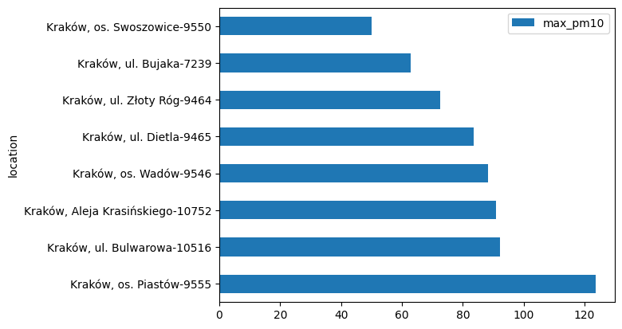

```python
plt.figure()
max_pm10.limit(10).toPandas().plot.barh(x='location')
```

### Task 1

Load data for several dozen locations in Poland over an extended period (as much as memory allows). Create a query that calculates the average concentration of a chosen parameter for each hour of the day (0-1, 1-2, ..., 23-24) for every location, and finds the hour at which this average was highest.

```python
def get_valid_s3_paths(location_ids, spark_session, target_count=30):
    valid_paths = []
    for loc_id in location_ids:
        path = f"s3a://openaq-data-archive/records/csv.gz/locationid={loc_id}/year=2022/month={{05,06}}/*.csv.gz"
        try:
            spark_session.read.format("csv").option("compression", "gzip").option("header", True).load(path)
            valid_paths.append(path)
            #print(f"Found valid path for location ID: {loc_id}")
        except Exception as e:
            if "PATH_NOT_FOUND" in str(e):
                pass
            else:
                print(f"Error loading data for location ID {loc_id}: {e}")

        if len(valid_paths) >= target_count:
            break

    return valid_paths
```

```python
pl_locations_df = locations_df.filter(locations_df.country_code == 'PL').select('name', 'id')
pl_location_ids = pl_locations_df.select("id").rdd.flatMap(lambda x: x).collect()
pl_30 = get_valid_s3_paths(pl_location_ids, spark, target_count=30)
```

```python
pl_30
```

```
['s3a://openaq-data-archive/records/csv.gz/locationid=4379/year=2022/month={05,06}/*.csv.gz',
 's3a://openaq-data-archive/records/csv.gz/locationid=4452/year=2022/month={05,06}/*.csv.gz',
 's3a://openaq-data-archive/records/csv.gz/locationid=6351/year=2022/month={05,06}/*.csv.gz',
 's3a://openaq-data-archive/records/csv.gz/locationid=6378/year=2022/month={05,06}/*.csv.gz',
 's3a://openaq-data-archive/records/csv.gz/locationid=6381/year=2022/month={05,06}/*.csv.gz',
 's3a://openaq-data-archive/records/csv.gz/locationid=6382/year=2022/month={05,06}/*.csv.gz',
 's3a://openaq-data-archive/records/csv.gz/locationid=6384/year=2022/month={05,06}/*.csv.gz',
 's3a://openaq-data-archive/records/csv.gz/locationid=6386/year=2022/month={05,06}/*.csv.gz',
 's3a://openaq-data-archive/records/csv.gz/locationid=6387/year=2022/month={05,06}/*.csv.gz',
 's3a://openaq-data-archive/records/csv.gz/locationid=6522/year=2022/month={05,06}/*.csv.gz',
 's3a://openaq-data-archive/records/csv.gz/locationid=7137/year=2022/month={05,06}/*.csv.gz',
 's3a://openaq-data-archive/records/csv.gz/locationid=7207/year=2022/month={05,06}/*.csv.gz',
 's3a://openaq-data-archive/records/csv.gz/locationid=7209/year=2022/month={05,06}/*.csv.gz',
 's3a://openaq-data-archive/records/csv.gz/locationid=7210/year=2022/month={05,06}/*.csv.gz',
 's3a://openaq-data-archive/records/csv.gz/locationid=7211/year=2022/month={05,06}/*.csv.gz',
 's3a://openaq-data-archive/records/csv.gz/locationid=7239/year=2022/month={05,06}/*.csv.gz',
 's3a://openaq-data-archive/records/csv.gz/locationid=7241/year=2022/month={05,06}/*.csv.gz',
 's3a://openaq-data-archive/records/csv.gz/locationid=7245/year=2022/month={05,06}/*.csv.gz',
 's3a://openaq-data-archive/records/csv.gz/locationid=7246/year=2022/month={05,06}/*.csv.gz',
 's3a://openaq-data-archive/records/csv.gz/locationid=7248/year=2022/month={05,06}/*.csv.gz',
 's3a://openaq-data-archive/records/csv.gz/locationid=7250/year=2022/month={05,06}/*.csv.gz',
 's3a://openaq-data-archive/records/csv.gz/locationid=7251/year=2022/month={05,06}/*.csv.gz',
 's3a://openaq-data-archive/records/csv.gz/locationid=7252/year=2022/month={05,06}/*.csv.gz',
 's3a://openaq-data-archive/records/csv.gz/locationid=7253/year=2022/month={05,06}/*.csv.gz',
 's3a://openaq-data-archive/records/csv.gz/locationid=7255/year=2022/month={05,06}/*.csv.gz',
 's3a://openaq-data-archive/records/csv.gz/locationid=7256/year=2022/month={05,06}/*.csv.gz',
 's3a://openaq-data-archive/records/csv.gz/locationid=7259/year=2022/month={05,06}/*.csv.gz',
 's3a://openaq-data-archive/records/csv.gz/locationid=7261/year=2022/month={05,06}/*.csv.gz',
 's3a://openaq-data-archive/records/csv.gz/locationid=7263/year=2022/month={05,06}/*.csv.gz',
 's3a://openaq-data-archive/records/csv.gz/locationid=7264/year=2022/month={05,06}/*.csv.gz']
```

```python
from functools import reduce
from pyspark.sql import DataFrame


def get_df_from_paths(s3_paths, spark_session, locations_df):
    if not s3_paths:
        return None

    correct_dfs = []
    for path in s3_paths:
      dfs = spark_session \
          .read \
          .format("csv") \
          .option("compression", "gzip") \
          .option("header", True) \
          .load(path)
      correct_dfs.append(dfs)

    df_all = reduce(DataFrame.unionByName, correct_dfs)

    df_typed = (
        df_all
        .withColumn("value", col("value").cast("double"))
        .withColumn("location_id", col("location_id").cast("long"))
        .withColumn("datetime", col("datetime").cast("timestamp"))
    )

    df_final = df_typed.join(
        locations_df.select("id", "name"),
        df_typed.location_id == locations_df.id,
        how='left'
    ).drop(locations_df.id)

    return df_final
```

```python
df_final = get_df_from_paths(pl_30, spark, pl_locations_df)
```

```python
df_final.printSchema()
```

```
root
 |-- location_id: long (nullable = true)
 |-- sensors_id: string (nullable = true)
 |-- location: string (nullable = true)
 |-- datetime: timestamp (nullable = true)
 |-- lat: string (nullable = true)
 |-- lon: string (nullable = true)
 |-- parameter: string (nullable = true)
 |-- units: string (nullable = true)
 |-- value: double (nullable = true)
 |-- name: string (nullable = true)
```

```python
df_final.select("name").distinct().show()
```

```
+--------------------+
|                name|
+--------------------+
|         Cesky Tesin|
|Vernovice-Dolni L...|
|Olesno, ul. Słowa...|
|           Czerniawa|
|Warszawa, ul. Toł...|
|Zakopane, ul. Sie...|
|Szczecin, ul. And...|
|Warszawa, ul. Wok...|
|Piastów, ul. Puła...|
|Suwałki, ul. Puła...|
|Koszalin, ul. Arm...|
|   Łódź, ul. Gdańska|
|Liniewko Kościerskie|
|Kościerzyna, ul. ...|
|Lębork, ul. Malcz...|
|  Kraków, ul. Bujaka|
|Konstancin-Jezior...|
|Warszawa, ul. Kon...|
|Płock, ul. Królow...|
|Włocławek, ul. Ok...|
+--------------------+
only showing top 20 rows
```

```python
df_final.select("name").distinct().count()
```

```
30
```

```python
from pyspark.sql.functions import hour, avg

PARAMETER = "co"

hour_avg_co = df_final \
  .filter(col("parameter") == PARAMETER) \
  .groupBy(
    col("name"),
    hour(col("datetime")).alias("hour")
  ) \
  .agg(avg(col("value")).alias("avg_value"))
```

```python
hour_avg_co.show()
```

```
+--------------------+----+------------------+
|                name|hour|         avg_value|
+--------------------+----+------------------+
|Zakopane, ul. Sie...|  22| 445.2250000000001|
|Zakopane, ul. Sie...|  16|          363.2908|
|Zakopane, ul. Sie...|   3|         396.91875|
|Zakopane, ul. Sie...|   4|393.67047619047617|
|Zakopane, ul. Sie...|  18|          349.0776|
|Zakopane, ul. Sie...|   5|403.18913043478256|
|Zakopane, ul. Sie...|  14|401.43679999999995|
|Zakopane, ul. Sie...|  15|364.69399999999996|
|Zakopane, ul. Sie...|   9| 362.4818181818182|
|Zakopane, ul. Sie...|  11| 419.6187499999999|
|Zakopane, ul. Sie...|   8| 400.8945833333333|
|Zakopane, ul. Sie...|   0| 429.3895833333333|
|Zakopane, ul. Sie...|  10| 425.5877272727273|
|Zakopane, ul. Sie...|  13| 372.2832000000001|
|Zakopane, ul. Sie...|  17|          339.8532|
|Zakopane, ul. Sie...|  12|          410.6588|
|Zakopane, ul. Sie...|  19|396.84479999999996|
|Zakopane, ul. Sie...|   2| 400.6054166666666|
|Zakopane, ul. Sie...|  21|465.79839999999996|
|Zakopane, ul. Sie...|   7|         402.38875|
+--------------------+----+------------------+
only showing top 20 rows
```

```python
hour_avg_co.cache()
```

```
DataFrame[name: string, hour: int, avg_value: double]
```

```python
from pyspark.sql.functions import max, col
from pyspark.sql import Window

w = Window.partitionBy('name')

hour_avg_co_with_max = hour_avg_co.withColumn('max_avg_value', max('avg_value').over(w))

highest_avg_hour_per_location = hour_avg_co_with_max.filter(col('avg_value') == col('max_avg_value')).drop('max_avg_value')
```

```python
highest_avg_hour_per_location.show(truncate=False)
```

```
+-------------------------------------------------+----+------------------+
|name                                             |hour|avg_value         |
+-------------------------------------------------+----+------------------+
|Koszalin, ul. Armii Krajowej                     |20  |200.6851515151515 |
|Lębork, ul. Malczewskiego                        |21  |232.92412000000002|
|Pila, ul. Kusocińskiego                          |21  |512.7884          |
|Piotrków Trybunalski, ul. Krakowskie Przedmieście|21  |480.3333333333333 |
|Włocławek, ul. Okrzei                            |4   |584.6             |
|Zakopane, ul. Sienkiewicza                       |21  |465.79839999999996|
|Łódź, ul. Gdańska                                |21  |430.6             |
+-------------------------------------------------+----+------------------+
```

```python
hour_avg_co.unpersist()
```

```
DataFrame[name: string, hour: int, avg_value: double]
```

### Task 2

For each location, find the highest average concentration of the selected parameter on a given day of the week (Mon-Sun) during the hours 8-20. Present the results sorted by location, and then in descending order by the calculated concentration. Create a visualization similar to the attached example.

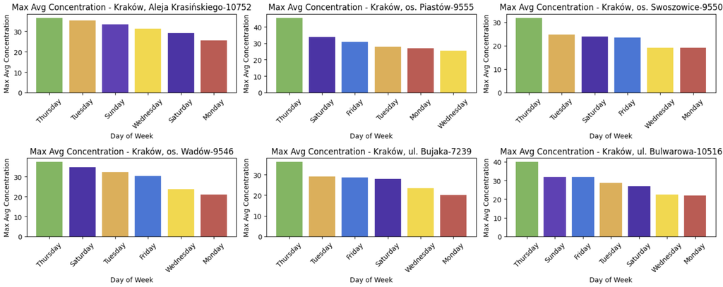

```python
from pyspark.sql.functions import date_format

pl_week_stats = df_final \
    .filter(col("parameter") == PARAMETER) \
    .filter(hour(col("datetime")).between(8, 20)) \
    .withColumn("weekday", date_format(col("datetime"), "EEEE")) \
    .groupBy("name", "weekday") \
    .agg(avg("value").alias("avg_value")) \
    .orderBy("name", "weekday")
```

```python
pl_week_stats.show(10)
```

```
+--------------------+---------+------------------+
|                name|  weekday|         avg_value|
+--------------------+---------+------------------+
|Koszalin, ul. Arm...|   Friday|164.20865384615385|
|Koszalin, ul. Arm...|   Monday|155.41912280701754|
|Koszalin, ul. Arm...| Saturday|152.91076923076923|
|Koszalin, ul. Arm...|   Sunday| 138.6130769230769|
|Koszalin, ul. Arm...| Thursday| 177.1078461538461|
|Koszalin, ul. Arm...|  Tuesday|166.33290322580646|
|Koszalin, ul. Arm...|Wednesday|174.39826923076922|
|Lębork, ul. Malcz...|   Friday| 86.44336153846153|
|Lębork, ul. Malcz...|   Monday|199.11132692307686|
|Lębork, ul. Malcz...| Saturday|145.61566538461537|
+--------------------+---------+------------------+
only showing top 10 rows
```

```python
from pyspark.sql.functions import max, col, rank
from pyspark.sql import Window

w = Window.partitionBy('name', 'weekday').orderBy(desc("avg_value"))

df2 = pl_week_stats \
  .withColumn("rank", rank().over(w)) \
  .filter(col("rank") == 1) \
  .select("name", "weekday", "avg_value")
```

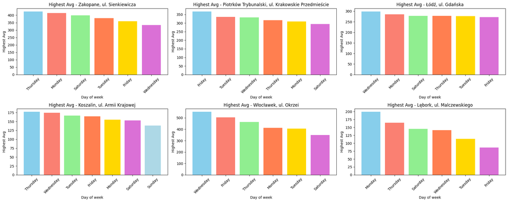

```python
import matplotlib.pyplot as plt
import numpy as np
import pandas as pd

locations_list = [loc['name'] for loc in df2.select('name').distinct().collect()]

rows, cols = 2, 3
fig, axes = plt.subplots(rows, cols, figsize=(20, 8))
axes = axes.flatten()

colors = ['skyblue', 'salmon', 'lightgreen', 'coral', 'gold', 'orchid', 'lightblue']

for i, loc in enumerate(locations_list):
    if i >= rows * cols:
        break
    loc_data = (
        df2
        .filter(col('name') == loc)
        .toPandas()
        .sort_values(by='avg_value', ascending=False)
    )
    ax = axes[i]

    bar_colors = [colors[j % len(colors)] for j in range(len(loc_data))]
    ax.bar(loc_data['weekday'].astype(str), loc_data['avg_value'], color=bar_colors)

    ax.set_title(f"Highest Avg - {loc}")
    ax.set_xlabel("Day of week")
    ax.set_ylabel("Highest Avg")
    ax.tick_params(axis='x', rotation=45)


for j in range(i + 1, rows * cols):
    fig.delaxes(axes[j])

plt.tight_layout()
plt.show()
```

### Task 3

Load data from three different countries, with 5 locations for each. Then, create a query that identifies the top 3 locations with the highest average PM10 concentration for each country.

```python
locations_df.select(col("country_code"), col("country_name")).distinct().tail(20)
```

```
[Row(country_code='GH', country_name='Ghana'),
 Row(country_code='KE', country_name='Kenya'),
 Row(country_code='PR', country_name='Puerto Rico'),
 Row(country_code='AZ', country_name='Azerbaijan'),
 Row(country_code='UA', country_name='Ukraine'),
 Row(country_code='MA', country_name='Morocco'),
 Row(country_code='EG', country_name='Egypt'),
 Row(country_code='PY', country_name='Paraguay'),
 Row(country_code='BA', country_name='Bosnia and Herzegovina'),
 Row(country_code='HK', country_name='Hong Kong'),
 Row(country_code='MX', country_name='Mexico'),
 Row(country_code='GI', country_name='Gibraltar'),
 Row(country_code='CV', country_name='Republic of Cabo Verde'),
 Row(country_code='KR', country_name='Republic of Korea'),
 Row(country_code='SK', country_name='Slovakia'),
 Row(country_code='IT', country_name='Italy'),
 Row(country_code='CH', country_name='Switzerland'),
 Row(country_code='AT', country_name='Austria'),
 Row(country_code='SI', country_name='Slovenia'),
 Row(country_code='CI', country_name="Côte d'Ivoire")]
```

```python
NO_locations_df = locations_df.filter(locations_df.country_code == 'NO').select('name', 'id')
NO_location_ids = NO_locations_df.select("id").rdd.flatMap(lambda x: x).collect()
NO_5 = get_valid_s3_paths(NO_location_ids, spark, target_count=5)
NO_5
```

```
['s3a://openaq-data-archive/records/csv.gz/locationid=2947/year=2022/month={05,06}/*.csv.gz',
 's3a://openaq-data-archive/records/csv.gz/locationid=5674/year=2022/month={05,06}/*.csv.gz',
 's3a://openaq-data-archive/records/csv.gz/locationid=6363/year=2022/month={05,06}/*.csv.gz',
 's3a://openaq-data-archive/records/csv.gz/locationid=6391/year=2022/month={05,06}/*.csv.gz',
 's3a://openaq-data-archive/records/csv.gz/locationid=6502/year=2022/month={05,06}/*.csv.gz']
```

```python
SI_locations_df = locations_df.filter(locations_df.country_code == 'SI').select('name', 'id')
SI_location_ids = SI_locations_df.select("id").rdd.flatMap(lambda x: x).collect()
SI_5 = get_valid_s3_paths(SI_location_ids, spark, target_count=5)
SI_5
```

```
['s3a://openaq-data-archive/records/csv.gz/locationid=2959/year=2022/month={05,06}/*.csv.gz',
 's3a://openaq-data-archive/records/csv.gz/locationid=7293/year=2022/month={05,06}/*.csv.gz',
 's3a://openaq-data-archive/records/csv.gz/locationid=10551/year=2022/month={05,06}/*.csv.gz',
 's3a://openaq-data-archive/records/csv.gz/locationid=10583/year=2022/month={05,06}/*.csv.gz',
 's3a://openaq-data-archive/records/csv.gz/locationid=10594/year=2022/month={05,06}/*.csv.gz']
```

```python
AT_locations_df = locations_df.filter(locations_df.country_code == 'AT').select('name', 'id')
AT_location_ids = AT_locations_df.select("id").rdd.flatMap(lambda x: x).collect()
AT_5 = get_valid_s3_paths(AT_location_ids, spark, target_count=5)
AT_5
```

```
['s3a://openaq-data-archive/records/csv.gz/locationid=2721/year=2022/month={05,06}/*.csv.gz',
 's3a://openaq-data-archive/records/csv.gz/locationid=2725/year=2022/month={05,06}/*.csv.gz',
 's3a://openaq-data-archive/records/csv.gz/locationid=2746/year=2022/month={05,06}/*.csv.gz',
 's3a://openaq-data-archive/records/csv.gz/locationid=2748/year=2022/month={05,06}/*.csv.gz',
 's3a://openaq-data-archive/records/csv.gz/locationid=2752/year=2022/month={05,06}/*.csv.gz']
```

```python
finalNO = get_df_from_paths(NO_5, spark, NO_locations_df)
finalSI = get_df_from_paths(SI_5, spark, SI_locations_df)
finalAT = get_df_from_paths(AT_5, spark, AT_locations_df)
```

```python
for final in [finalNO, finalSI, finalAT]:
  final.printSchema()
```

```
root
 |-- location_id: long (nullable = true)
 |-- sensors_id: string (nullable = true)
 |-- location: string (nullable = true)
 |-- datetime: timestamp (nullable = true)
 |-- lat: string (nullable = true)
 |-- lon: string (nullable = true)
 |-- parameter: string (nullable = true)
 |-- units: string (nullable = true)
 |-- value: double (nullable = true)
 |-- name: string (nullable = true)

root
 |-- location_id: long (nullable = true)
 |-- sensors_id: string (nullable = true)
 |-- location: string (nullable = true)
 |-- datetime: timestamp (nullable = true)
 |-- lat: string (nullable = true)
 |-- lon: string (nullable = true)
 |-- parameter: string (nullable = true)
 |-- units: string (nullable = true)
 |-- value: double (nullable = true)
 |-- name: string (nullable = true)

root
 |-- location_id: long (nullable = true)
 |-- sensors_id: string (nullable = true)
 |-- location: string (nullable = true)
 |-- datetime: timestamp (nullable = true)
 |-- lat: string (nullable = true)
 |-- lon: string (nullable = true)
 |-- parameter: string (nullable = true)
 |-- units: string (nullable = true)
 |-- value: double (nullable = true)
 |-- name: string (nullable = true)
```

```python
from pyspark.sql.functions import avg, col, desc

def top_3_with_high_pm10(data, PARAMETER="pm10"):
  top_avg_param = data \
    .filter(col("parameter") == PARAMETER) \
    .groupBy(
      col("name")
    ) \
    .agg(avg(col("value")).alias("avg_value")) \
    .orderBy(col("avg_value").desc()).limit(3)

  return top_avg_param
```

```python
top_3_at = top_3_with_high_pm10(finalAT)
top_3_at.show(truncate=False)
```

```
+---------------+------------------+
|name           |avg_value         |
+---------------+------------------+
|AT0KLH1        |13.430446455732135|
|Wiener Neustadt|12.10625          |
|NET.04         |11.763259771740708|
+---------------+------------------+
```

```python
top_3_no = top_3_with_high_pm10(finalNO)
top_3_no.show(truncate=False)
```

```
+-----------+------------------+
|name       |avg_value         |
+-----------+------------------+
|Olav V gate|15.405708358695655|
|Sverresgate|15.135051546391747|
|Moheia Vest|11.744151898753891|
+-----------+------------------+
```

```python
top_3_si = top_3_with_high_pm10(finalSI)
top_3_si.show(truncate=False)
```

```
+-----------+------------------+
|name       |avg_value         |
+-----------+------------------+
|Koper      |18.13142174432497 |
|LJ Bežigrad|17.31433506044905 |
|MB Titova  |17.098615916955016|
+-----------+------------------+
```

### Task 4

Create a query that lists locations for which the average daily concentration of parameter p exceeded the value w for more than n days during the study period.

```python
from pyspark.sql.functions import count, date_format
def localizations_over_param_value(data, parameter, value, days):

  daily_avg = data \
    .filter(col("parameter") == parameter) \
    .groupBy(
      col("name"),
      date_format(col("datetime"), "yyyy-MM-dd").alias("day")
    ) \
    .agg(avg(col("value")).alias("daily_avg_value"))

  data_over_value = daily_avg.filter(col("daily_avg_value") > value)

  localizations = data_over_value \
    .groupBy(col("name")) \
    .agg(count("*").alias("days_over_value"))

  return localizations.filter(col("days_over_value") > days)
```

```python
co_days_over_value = localizations_over_param_value(df_final, "co", 0.1, 10)
co_days_over_value.show()
```

```
+--------------------+---------------+
|                name|days_over_value|
+--------------------+---------------+
|Zakopane, ul. Sie...|             33|
|Piotrków Trybunal...|             34|
|   Łódź, ul. Gdańska|             34|
|Koszalin, ul. Arm...|             38|
|Włocławek, ul. Ok...|             34|
|Lębork, ul. Malcz...|             34|
|Pila, ul. Kusociń...|             34|
+--------------------+---------------+
```

```python
pm25_days_over_value = localizations_over_param_value(df_final, "pm25", 0.1, 30)
pm25_days_over_value.show()
```

```
+--------------------+---------------+
|                name|days_over_value|
+--------------------+---------------+
|Vernovice-Dolni L...|             34|
|Szczecin, ul. And...|             34|
|Legionowo, ul. Ze...|             34|
|  Łódź, ul. Czernika|             34|
|Suwałki, ul. Puła...|             34|
|Piastów, ul. Puła...|             34|
|Konstancin-Jezior...|             32|
|Włocławek, ul. Ok...|             34|
|Kościerzyna, ul. ...|             38|
|         Cesky Tesin|             34|
|Warszawa, ul. Wok...|             34|
|Lębork, ul. Malcz...|             34|
+--------------------+---------------+
```

```python
pm25_days_over_value = localizations_over_param_value(df_final, "pm25", 5, 15)
pm25_days_over_value.show()
```

```
+--------------------+---------------+
|                name|days_over_value|
+--------------------+---------------+
|Ełk, ul. Piłsudsk...|             20|
|Vernovice-Dolni L...|             34|
|Szczecin, ul. And...|             32|
|Warszawa, ul. Toł...|             19|
|Legionowo, ul. Ze...|             30|
|  Łódź, ul. Czernika|             26|
|Suwałki, ul. Puła...|             28|
|          Działoszyn|             16|
|Piastów, ul. Puła...|             28|
|Konstancin-Jezior...|             31|
|Włocławek, ul. Ok...|             34|
|Kościerzyna, ul. ...|             29|
|         Cesky Tesin|             32|
|Warszawa, ul. Wok...|             27|
|Lębork, ul. Malcz...|             32|
+--------------------+---------------+
```

```python
pm25_days_over_value = localizations_over_param_value(df_final, "pm25", 30.0, 5)
pm25_days_over_value.show()
```

```
+----+---------------+
|name|days_over_value|
+----+---------------+
+----+---------------+
```

```python
o3_days_over_value = localizations_over_param_value(df_final, "o3", 1, 31)
o3_days_over_value.show()
```

```
+--------------------+---------------+
|                name|days_over_value|
+--------------------+---------------+
|Ełk, ul. Piłsudsk...|             34|
|Zakopane, ul. Sie...|             34|
|Szczecin, ul. And...|             33|
|Olesno, ul. Słowa...|             34|
|Legionowo, ul. Ze...|             34|
|  Łódź, ul. Czernika|             34|
|Oława, ul. Żołnie...|             34|
|Warszawa, ul. Kon...|             34|
|Toruń, ul. Dziewu...|             34|
|           Czerniawa|             38|
|Piastów, ul. Puła...|             34|
|Piotrków Trybunal...|             34|
|  Kraków, ul. Bujaka|             33|
|Warszawa, ul. Wok...|             34|
|Liniewko Kościerskie|             34|
|Lębork, ul. Malcz...|             34|
+--------------------+---------------+
```